# Regression Analysis

### Random Forest

Given the linear models are only capture the linear relationship between the predictors and the popularity, we also try to use the random forest to see if the non-linear relationship could be captured. Also, random forest model was employed to identify the most influential predictors of song popularity.

```r
rf_model <- randomForest(
    track_popularity ~ danceability + energy + loudness +
                      acousticness + instrumentalness + liveness +
                      valence + tempo + duration_ms + track_album_release_year +
                      playlist_genre,
    data = train_data,
    ntree = 100,
    importance = TRUE
)

# 3. Check model performance
rf_predictions <- predict(rf_model, test_data)

rf_rmse <- sqrt(mean((test_data$track_popularity - rf_predictions)^2))
print(paste("Random Forest RMSE:", rf_rmse))
```

```
## [1] "Random Forest RMSE: 20.8437013730635"
```

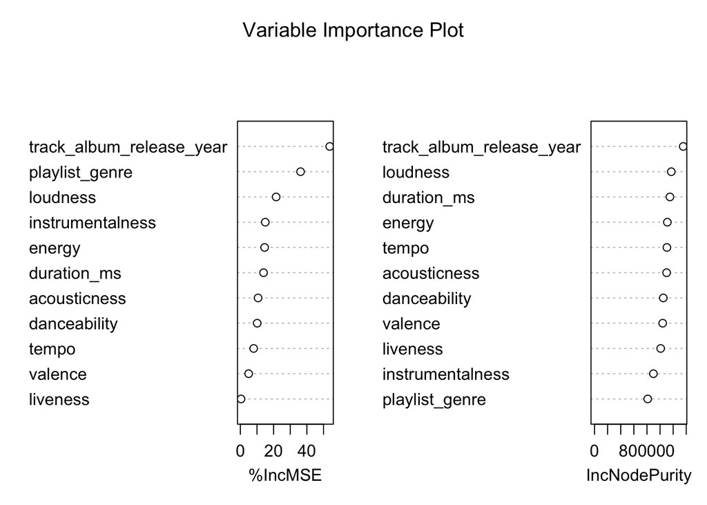

```r
# 4. Variable Importance
varImpPlot(rf_model,
           main = "Variable Importance Plot")
```

```r
# Print importance scores
importance(rf_model)
```

```
##                             %IncMSE IncNodePurity
## danceability             10.1282001     1049535.0
## energy                   14.5737002     1111777.6
## loudness                 21.5251216     1171401.8
## acousticness             10.6630964     1100338.4
## instrumentalness         15.0012745      898656.7
## liveness                  0.4183691     1009382.6
## valence                   5.0062639     1040425.3
## tempo                     8.0020704     1104929.7
## duration_ms              13.9628699     1151062.3
## track_album_release_year 53.7551173     1354326.6
## playlist_genre           36.2088657      811669.5
```

```r
# 5. Tune hyperparameters
ctrl <- trainControl(
    method = "cv",
    number = 3,
    verboseIter = TRUE
)

tuning_grid <- expand.grid(
    mtry = seq(2, 6, by = 2)  # Number of variables to try at each split
)

rf_tuned <- train(
    track_popularity ~ danceability + energy + loudness +
                      acousticness + instrumentalness + liveness +
                      valence + tempo + duration_ms + track_album_release_year +
                      playlist_genre,
    data = train_data,
    method = "rf",
    tuneGrid = tuning_grid,
    trControl = ctrl
)
print(rf_tuned$bestTune)
```

```
##   mtry
## 1    2
```

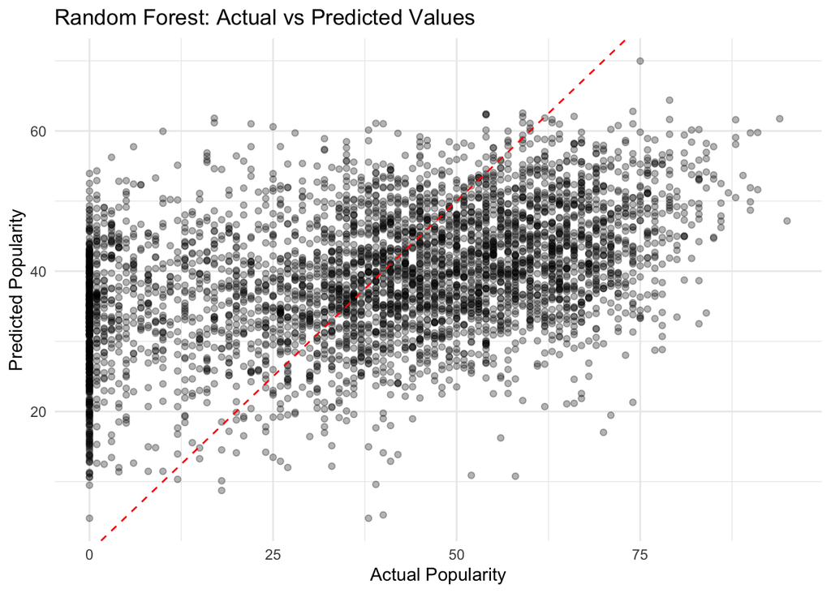

```r
# 6. Final model with best parameters
final_rf <- randomForest(
    track_popularity ~ danceability + energy + loudness +
                      acousticness + instrumentalness + liveness +
                      valence + tempo + duration_ms + track_album_release_year +
                      playlist_genre,
    data = train_data,
    ntree = 100,
    mtry = rf_tuned$bestTune$mtry
)

# 7. Compare with original linear model
final_rf_predictions <- predict(final_rf, test_data)
rf_rmse <- sqrt(mean((test_data$track_popularity - final_rf_predictions)^2))

plot_data <- data.frame(
    Actual = test_data$track_popularity,
    Predicted = final_rf_predictions
)

ggplot(plot_data, aes(x = Actual, y = Predicted)) +
    geom_point(alpha = 0.3) +
    geom_abline(intercept = 0, slope = 1, color = "red", linetype = "dashed") +
    labs(title = "Random Forest: Actual vs Predicted Values",
         x = "Actual Popularity",
         y = "Predicted Popularity") +
    theme_minimal()
```

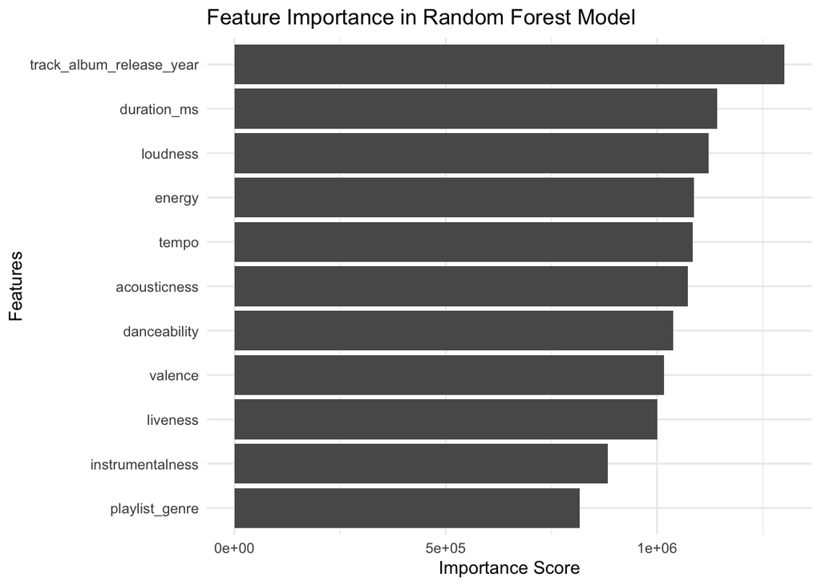

```r
# 8. Feature importance visualization
importance_df <- data.frame(
    Feature = rownames(importance(final_rf)),
    Importance = importance(final_rf)[,1]
) %>%
    arrange(desc(Importance))

ggplot(importance_df, aes(x = reorder(Feature, Importance), y = Importance)) +
    geom_bar(stat = "identity") +
    coord_flip() +
    theme_minimal() +
    labs(title = "Feature Importance in Random Forest Model",
         x = "Features",
         y = "Importance Score")
```

The random forest model identified the following key features influencing song popularity:

- **Track Album Release Year**: The most significant predictor, suggesting that newer songs may tend to have higher popularity scores.
- **Duration (ms)**: Indicates that song length might play a role in popularity.
- **Loudness and Energy**: These features, which are highly correlated, both significantly contribute to a track’s appeal.
- **Acousticness**: A strong negative relationship with energy, influencing popularity depending on the type of song.
- **Tempo and Danceability**: Contribute to the rhythmic and dynamic feel of the track, impacting its popularity.
- **Other Factors**: Valence, liveness, instrumentalness, and playlist genre were also important but to a lesser extent.

## Exploring Transformations and Simplification

To improve predictive power and address potential heteroscedasticity, several methods were applied to transform the `track popularity` variable. These included:

- **Log Transformation**: Reduces skewness and helps stabilize variance for heavily skewed data.
- **Square Root Transformation**: Useful for moderate skewness, providing a balanced transformation.
- **Box-Cox Transformation**: Applies a parameterized transformation to optimize normality and homoscedasticity.

These transformations were evaluated to determine their effect on the predictive accuracy and the overall model performance.

### Distribution Transformation

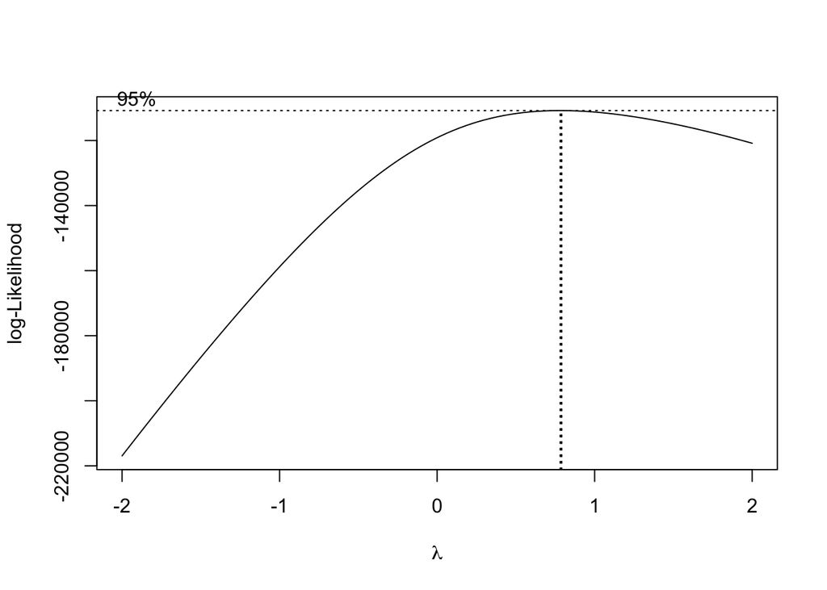

```r
# Log transformation
model_log <- lm(log1p(track_popularity) ~ danceability + energy + loudness +
                acousticness + instrumentalness + liveness +
                valence + tempo + duration_ms + song_age,
                data = train_data)

# Square root transformation
model_sqrt <- lm(sqrt(track_popularity) ~ danceability + energy + loudness +
                 acousticness + instrumentalness + liveness +
                 valence + tempo + duration_ms + song_age,
                 data = train_data)
shifted_popularity <- train_data$track_popularity + 1  # Add 1 to handle zeros

# Box-Cox transformation
bc <- boxcox(shifted_popularity ~ danceability + energy + loudness +
             acousticness + instrumentalness + liveness +
             valence + tempo + duration_ms + song_age,
             data = train_data)
```

```r
# Find optimal lambda
lambda <- bc$x[which.max(bc$y)]

# Apply Box-Cox transformation
model_boxcox <- lm((track_popularity^lambda - 1)/lambda ~ danceability + energy +
                   loudness + acousticness + instrumentalness + liveness +
                   valence + tempo + duration_ms + song_age,
                   data = train_data)
```

The Lambda is close to 1, which means the original model might be better. But we still need to check the distribution after transformation.

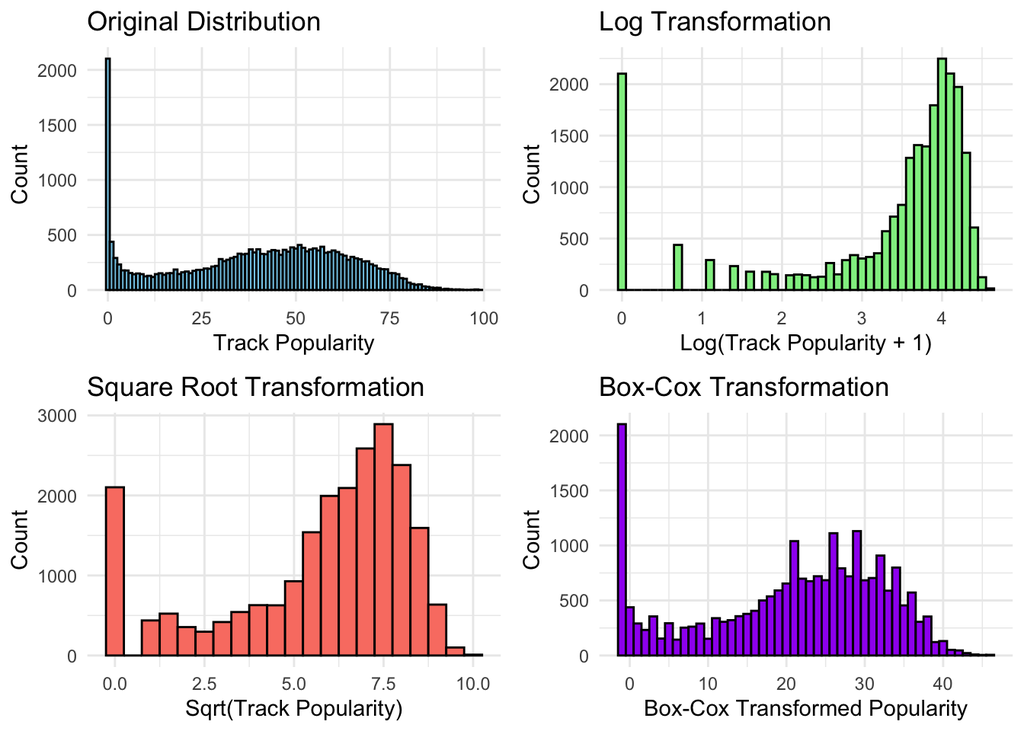

```r
p1 <- ggplot(train_data, aes(x = track_popularity)) +
  geom_histogram(binwidth = 1, fill = "skyblue", color = "black") +
  labs(title = "Original Distribution", x = "Track Popularity", y = "Count") +
  theme_minimal()


## popularity score could be 0
p2 <- ggplot(train_data, aes(x = log1p(track_popularity))) +
  geom_histogram(binwidth = 0.1, fill = "lightgreen", color = "black") +
  labs(title = "Log Transformation", x = "Log(Track Popularity + 1)", y = "Count") +
  theme_minimal()


p3 <- ggplot(train_data, aes(x = sqrt(track_popularity))) +
  geom_histogram(binwidth = 0.5, fill = "salmon", color = "black") +
  labs(title = "Square Root Transformation", x = "Sqrt(Track Popularity)", y = "Count") +
  theme_minimal()

p4 <- ggplot(train_data, aes(x = (track_popularity^lambda - 1)/lambda)) +
  geom_histogram(binwidth = 1, fill = "purple", color = "black") +
  labs(title = "Box-Cox Transformation", x = "Box-Cox Transformed Popularity", y = "Count") +
  theme_minimal()

grid.arrange(p1, p2, p3, p4, ncol = 2)
```

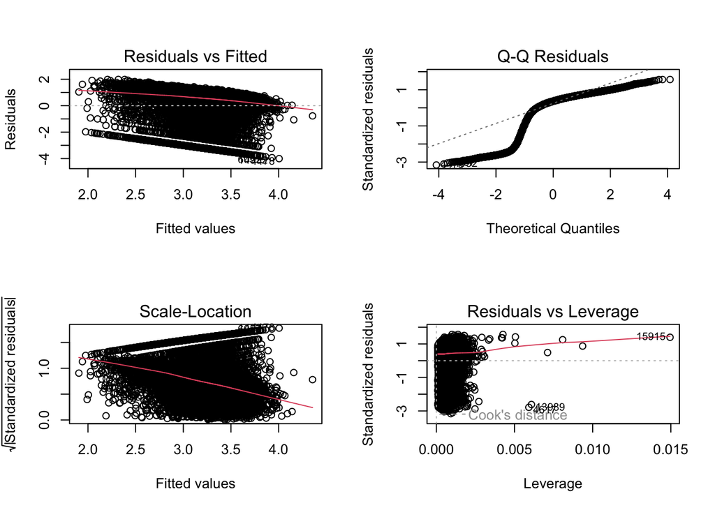

```r
check_residuals <- function(model) {
    par(mfrow = c(2,2))
    plot(model)
}

check_residuals(model_log)
```